# Part II - Factors affect students' academic performance and learning time

## Investigation Overview

This project aims to explore whether certain background factors can affect students' academic performance and how much time they spend learning.

We will first take a look at the distribution of scores and learning time. Then we will see the impact of background factors such as gender, OECD membership, parents'education on students' performance and study time.

## Dataset Overview

PISA is the global survey that assesses the competencies of 15-year-old students in reading, mathematics and science, as well as to understand their family backgrounds and educational systems. The dataset has 485,490 student records grouped in 636 columns. Here, I only focused on some features of interest such as country of residence, OECD membership, student's gender, parents' education level; academic performance on Math, Science, Reading along with the corresponding learning time.

- The PISA zip file (325 MB) is provided on the Udacity learning site [HERE](https://www.google.com/url?q=https://s3.amazonaws.com/udacity-hosted-downloads/ud507/pisa2012.csv.zip&sa=D&ust=1581581520574000).
- Extract the zip file above, we have a csv file (2.75 GB) named *pisa2012.csv*.
- Details about the data dictionary can be found [HERE](https://www.google.com/url?q=https://s3.amazonaws.com/udacity-hosted-downloads/ud507/pisadict2012.csv&sa=D&ust=1554482573645000).

```python
# import all packages and set plots to be embedded inline
import numpy as np
import pandas as pd
import matplotlib.pyplot as plt
import seaborn as sb

%matplotlib inline

# suppress warnings from final output
import warnings
warnings.simplefilter("ignore")
```

```python
# load in the dataset into a pandas dataframe
df_copy = pd.read_csv('pisa2012_clean.csv')
```

```python
## Data wrangling
ed_parents = ['No Education', 'Primary Education', 'Lower Secondary', 'Upper Secondary',
            'Post Secondary', 'Vocational Tertiary', 'Post Graduate']

# Return all educational levels with categories and orders
ed_levels = pd.api.types.CategoricalDtype(ordered=True, categories=ed_parents)

# Convert the 2 educational columns into an ordered categorical type
df_copy['father_education'] = df_copy['father_education'].astype(ed_levels)
df_copy['mother_education'] = df_copy['mother_education'].astype(ed_levels)

df_copy.info()
```

```
<class 'pandas.core.frame.DataFrame'>
Int64Index: 485490 entries, 0 to 485489
Data columns (total 13 columns):
 #   Column                  Non-Null Count   Dtype
---  ------                  --------------   -----
 0   country                 485490 non-null  object
 1   oecd                    485490 non-null  object
 2   gender                  485490 non-null  object
 3   father_education        452903 non-null  category
 4   mother_education        467085 non-null  category
 5   learning_math_time      283303 non-null  float64
 6   learning_science_time   270914 non-null  float64
 7   learning_language_time  282866 non-null  float64
 8   math_score              485490 non-null  float64
 9   reading_score           485490 non-null  float64
 10  science_score           485490 non-null  float64
 11  total_score             485490 non-null  float64
 12  total_learning_time     261497 non-null  float64
dtypes: category(2), float64(8), object(3)
memory usage: 45.4+ MB
```

## 1. Distribution of Scores

The dataset includes subject scores in mathematics, science, and reading, which vary between 200 and 800. All histogram of scores follows a clear normal distribution. The total scores also exhibit a normal distribution pattern, suggesting that the scores might have undergone standardization.

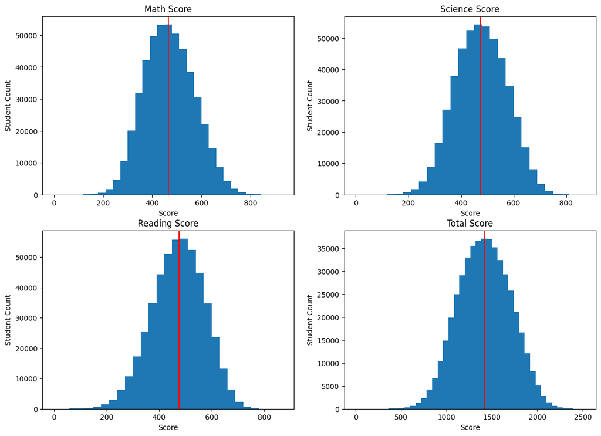

```python
# Create a function to plot histograms
def histogram (col, binsize, xlabel=None):
    bins = np.arange(0, df_copy[col].max()+binsize, binsize)
    plt.hist(data = df_copy, x = col, bins = bins)
    plt.title('{}'.format(col.replace('_', ' ').title()))
    plt.xlabel(xlabel)
    plt.ylabel('Student Count')
    plt.axvline(x = df_copy[col].median(), color = 'red')

# Set the plot dimensions
plt.figure(figsize = [14, 10])

# Create a dictionary to map positions with columns
scores_dict = {1:'math_score', 2:'science_score', 3:'reading_score', 4:'total_score'}

# Plot
for pos, col in scores_dict.items():
    plt.subplot(2, 2, pos)
    if pos == 4:
        histogram(col, binsize = 60, xlabel = 'Score')
    else:
        histogram(col, binsize = 30, xlabel = 'Score')
```

## 2. Distribution of Learning time

All distributions are right-skewed. The peak for each subject's learning time is about 180-220 minutes per week

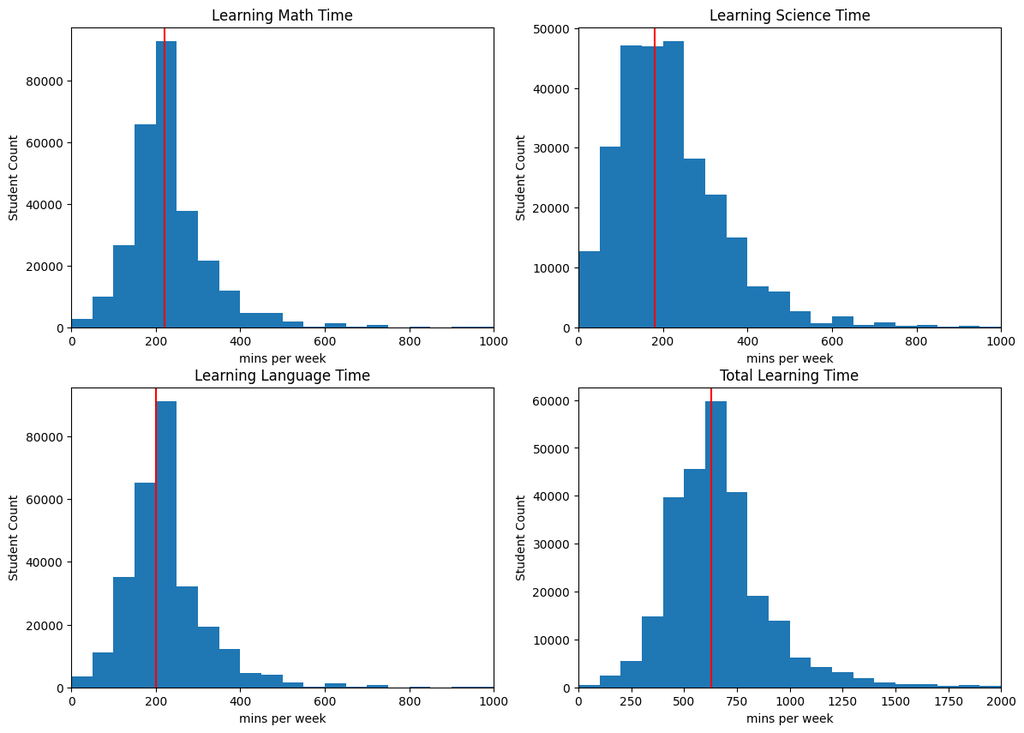

```python
# Set plot dimensions
plt.figure(figsize = [14, 10])

# Create a dictionary to map positions with columns
learning_time_dict = {1:'learning_math_time', 2:'learning_science_time', 3:'learning_language_time', 4:'total_learning_time'}

# Plot all histograms
for pos, col in learning_time_dict.items():
    plt.subplot(2, 2, pos)
    if pos == 4:
        histogram(col, binsize = 100, xlabel='mins per week')
        plt.xlim(0, 2000)
    else:
        histogram(col, binsize = 50, xlabel='mins per week')
        plt.xlim(0, 1000)
```

## 3. Scores by Gender

Overall, male and female students have similar total scores. Female students have better performance in Reading while male students perform slightly better in Math. Both genders perform equally well in Science.

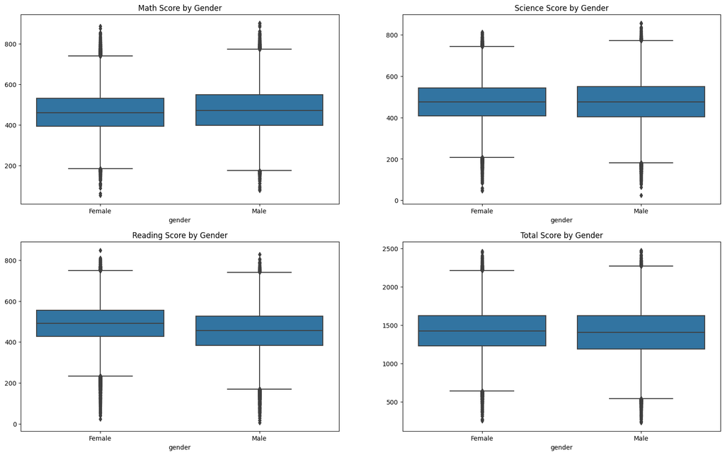

```python
# Set plot dimensions
plt.figure(figsize = [20, 12])

# Set base color
base_color = sb.color_palette()[0]

for pos, col in scores_dict.items():
    ax = plt.subplot(2, 2, pos)
    sb.boxplot(data=df_copy, x='gender', y=col, color=base_color)
    plt.title('{} by Gender'.format(col.replace('_', ' ').title()))
    ax.set_ylabel(None)
```

## 4. Scores by OECD membership

OECD countries have better performance in all subjects than non-OECD countries.

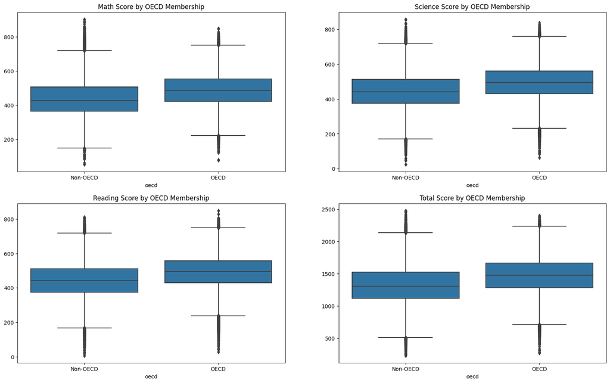

```python
# Set plot dimensions
plt.figure(figsize = [20, 12])

# Plot
for pos, col in scores_dict.items():
    ax = plt.subplot(2, 2, pos)
    sb.boxplot(data=df_copy, x='oecd', y=col, color=base_color)
    plt.title('{} by OECD Membership'.format(col.replace('_', ' ').title()))
    ax.set_ylabel(None)
```

## 5. Total score by parents' education

A similar trend can be seen between both parents with their children's total score. Students whose parents have higher level of education are more likely to perform better. But for parents with educational levels from Upper Secondary to Vocational Tertiary, the difference in their children's performance is less significant.

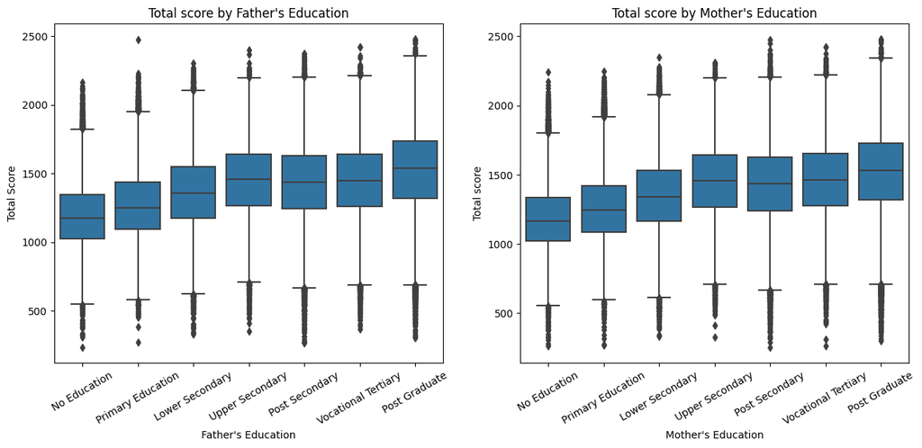

```python
plt.figure(figsize=[15,6])

plt.subplot(1,2,1)
sb.boxplot(data = df_copy, x = 'father_education', y = 'total_score', color=base_color)
plt.xticks(rotation = 30)
plt.title('Total score by Father\'s Education')
plt.xlabel('Father\'s Education')
plt.ylabel('Total Score')

plt.subplot(1,2,2)
sb.boxplot(data = df_copy, x = 'mother_education', y = 'total_score', color=base_color)
plt.xticks(rotation = 30)
plt.title('Total score by Mother\'s Education')
plt.xlabel('Mother\'s Education')
plt.ylabel('Total score');
```

## 6. Correlation between Scores

All scores show a positive correlation, suggesting that if a student performs well in either of the 3 subjects, he or she also performs well in the other two. Notably, the graph about Math and Science has the highest level of density, so these two subjects have the strongest correlation.

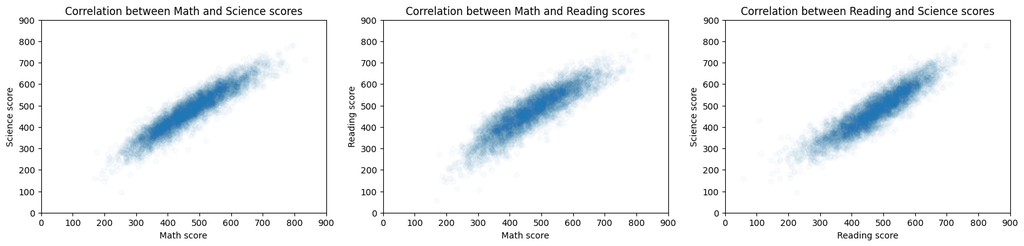

```python
# Create a sample
df_sample = df_copy.sample(5000)

# Set figure dimensions
plt.figure(figsize = [20, 4])

# Plot
ax2 = plt.subplot(1, 3, 1)
plt.scatter(data = df_sample, x = 'math_score', y = 'science_score', alpha = 1/40);
plt.xlabel('Math score')
plt.ylabel('Science score')
ax2.set_title('Correlation between Math and Science scores');

ax1 = plt.subplot(1, 3, 2)
plt.scatter(data = df_sample, x = 'math_score', y = 'reading_score', alpha = 1/40);
plt.xlabel('Math score')
plt.ylabel('Reading score')
ax1.set_title('Correlation between Math and Reading scores');

ax3 = plt.subplot(1, 3, 3)
plt.scatter(data = df_sample, x = 'reading_score', y = 'science_score', alpha = 1/40);
plt.xlabel('Reading score')
plt.ylabel('Science score')
ax3.set_title('Correlation between Reading and Science scores');

# Set the same axis ranges for all plots
plots = [ax1, ax2, ax3]
for ax in plots:
    ax.set_xlim([0, 900])
    ax.set_ylim([0, 900])
```

## 7. Scores by Gender and OECD membership

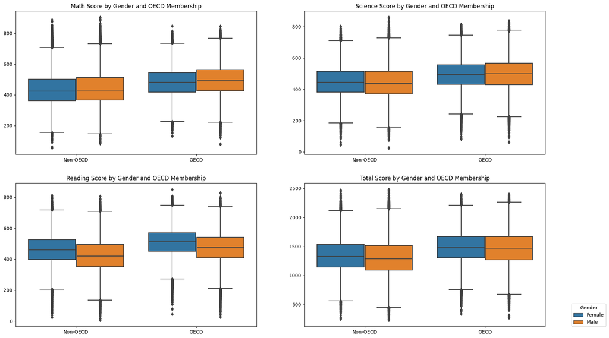

```python
# Set figure dimensions
plt.figure(figsize=[20, 12])

# Plot
for pos, col in scores_dict.items():
    ax = plt.subplot(2, 2, pos)
    sb.boxplot(data=df_copy, x='oecd', y=col, hue='gender')
    plt.title('{} by Gender and OECD Membership'.format(col.replace('_', ' ').title()))
    ax.set(xlabel=None, ylabel=None)
    if pos == 4:
        ax.legend(title="Gender", loc='center left', bbox_to_anchor=(1.1, 0.08))
    else:
        ax.get_legend().remove()
```

## 8. Total learning time by Gender and OECD membership

While females and males have the same learning time in non-OECD countries, males have longer learning time than females in OECD countries. Interestingly, the learning time of female students in non-OECD countries is slightly longer than those from OECD countries.

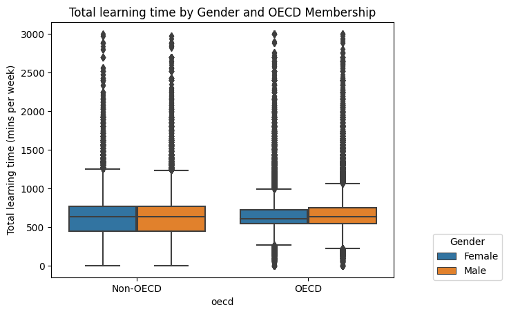

```python
sb.boxplot(data=df_copy, x='oecd', y='total_learning_time', hue='gender')
plt.title('Total learning time by Gender and OECD Membership')
plt.legend(title="Gender", loc='center left', bbox_to_anchor=(1.1, 0.08))
plt.ylabel('Total learning time (mins per week)');
```

```python
# Turn this to code block and run to get the slide deck
!jupyter nbconvert "Part_II_slide_deck.ipynb" --to slides --post serve --no-input --no-prompt
```